# R Notebook

```r
titanic <- read_csv("../data/titanic_decision_tree_data.csv")
shuffle_index <- sample(1:nrow(titanic))


titanic <- titanic[shuffle_index, ]
```

## Question 1

Cleaning up the data is always the first step. Do the following:

- Take only observations which have a `survived` flag (i.e. that aren’t missing)
- Turn your important variables into factors (sex, survived, pclass, embarkation)
- Create an `age_status` variable which groups individuals under (and including) 16 years of age into a category called “child” category and those over 16 into a category called “adult”.
- Drop the NA
- Drop any variables you don’t need (`X1`, `passenger_id`, `name`, `ticket`, `far`, `cabin`)

If you need help doing this, the code is below, but please try it yourself first so you can learn!

- Take only observations which have a `survived` flag (i.e. that aren’t missing)

```r
titanic_clean <- titanic %>%
  filter(survived == 0 | survived == 1)
```

Turn your important variables into factors (sex, survived, pclass, embarkation)

[output not shown]

[output cut: 881 more lines]

Create an `age_status` variable which groups individuals under (and including) 16 years of age into a category called “child” category and those over 16 into a category called “adult”

```r
titanic_clean_st <- titanic_clean %>%
  mutate(age_status = as.factor(if_else(age <= 16, "child", "adult")))
```

Drop the NA  
* Drop any variables you don’t need (`X1`, `passenger_id`, `name`, `ticket`, `far`, `cabin`)

```r
titanic_clean_st <-
titanic_clean_st %>%
  janitor::clean_names() %>%
  select(-x1, -passenger_id, -name, - ticket, -fare, -cabin) %>%
  drop_na()
```

[output not shown]

fixing survied

```r
titanic_clean_st <- titanic_clean_st %>%
  mutate(survived_flag = factor(survived, levels = c(0,1), labels = c("No", "Yes"))) %>%
  select(-survived)
```

## Question 2

Have a look at your data and create some plots to ensure you know what you’re working with before you begin. Write a summary of what you have found in your plots. Which variables do you think might be useful to predict whether or not people are going to die? Knowing this before you start is the best way to have a sanity check that your model is doing a good job.

```r
titanic_clean_st %>%
  skimr::skim() %>% view
```

[figure not shown]

Can see more people died in the data set

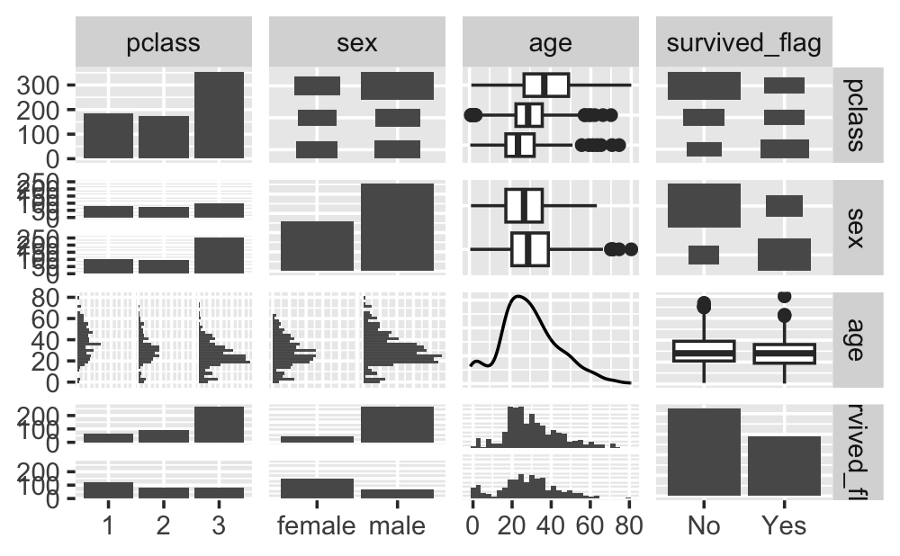

```r
titanic_clean_st %>%
  select(1:3, survived_flag) %>%
  ggpairs()
```

can see age doesnt look that interesting, while sex and pclass look good!

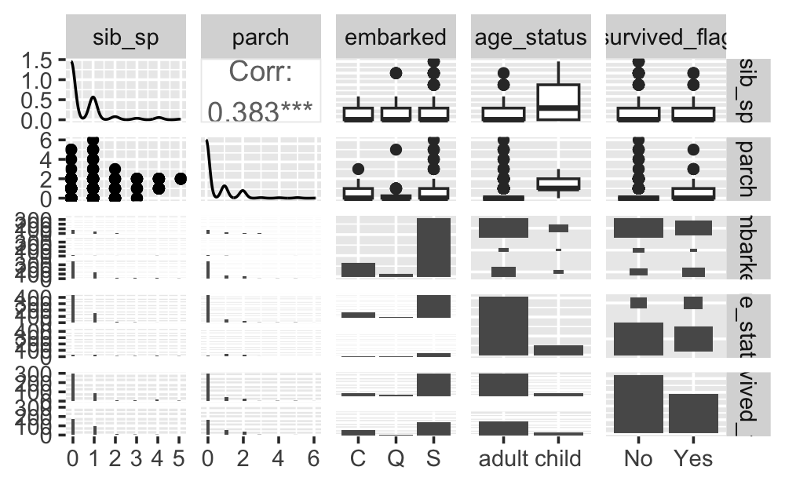

```r
titanic_clean_st %>%
  select(4:8) %>%
  ggpairs()
```

parch and age_status looks interesting

I would think:

class, gender, age_class would be the ones to look at

## Question 3

Now you can start to build your model. Create your testing and training set using an appropriate split. Check you have balanced sets. Write down why you chose the split you did and produce output tables to show whether or not it is balanced. [**Extra** - if you want to force balanced testing and training sets, have a look at the `stratified()` function in package `splitstackshape` (you can specify multiple variables to stratify on by passing a vector of variable names to the `group` argument, and get back testing and training sets with argument `bothSets = TRUE`)]

80% training, 20% testing - as good abmount of data for this split ratio

```r
n_data <- nrow(titanic_clean_st)

test_index <- sample(1:n_data, size = n_data*0.2)


titanic_test <- slice(titanic_clean_st, test_index)
titanic_train <- slice(titanic_clean_st, -test_index)
```

```r
titanic_test %>%
  janitor::tabyl(survived_flag)
```

```
 survived_flag  n   percent
            No 85 0.5985915
           Yes 57 0.4014085
```

```r
titanic_train %>%
  janitor::tabyl(survived_flag)
```

```
 survived_flag   n   percent
            No 339 0.5947368
           Yes 231 0.4052632
```

looooooking goooood! This shows the test and train data are both similar based.

## Question 4

Create your decision tree to try and predict survival probability using an appropriate method, and create a decision tree plot.

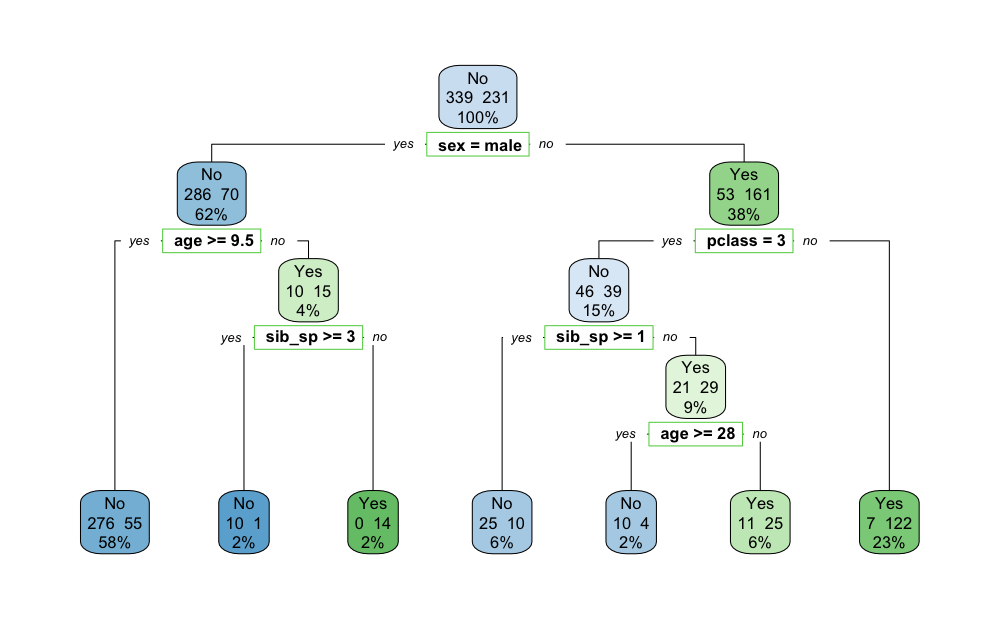

```r
titanic_fit <- rpart(
  formula = survived_flag ~ .,
  data = titanic_train,
  method = "class"
)

rpart.plot(titanic_fit,
           yesno = 2,
           type = 2,
           fallen.leaves = T,
           faclen = 6,
           digits = 2,
           split.border.col = 11,
           extra = 101)
```

```r
NA
NA
```

## Question 5

Write down what this tells you, in detail. What variables are important? What does each node tell you? Who has the highest chance of surviving? Who has the lowest? Provide as much detail as you can.

Important:

SEX AGE SIB PCLASS

each node tells us prediction of survival and the number that survived or not

## Question 6

Test and add your predictions to your data. Create a confusion matrix. Write down in detail what this tells you for this specific dataset.

```r
titanic_clean_pred <- titanic_test %>%
  add_predictions(titanic_fit, type = "class")
```

```r
titanic_clean_pred %>%
  select(sex, age, sib_sp, pclass, pred, survived_flag)
```

| sex | age | sib_sp | pclass | pred | survived_flag |
| --- | --- | --- | --- | --- | --- |
| male | 40.00 | 1 | 3 | No | No |
| male | 28.00 | 0 | 3 | No | No |
| male | 25.00 | 0 | 3 | No | No |
| male | 38.00 | 1 | 1 | No | Yes |
| female | 38.00 | 1 | 1 | Yes | Yes |
| female | 1.00 | 1 | 3 | No | Yes |
| female | 22.00 | 0 | 1 | Yes | Yes |
| male | 29.00 | 0 | 3 | No | No |
| male | 23.50 | 0 | 3 | No | No |
| male | 45.50 | 0 | 3 | No | No |

[output cut: 132 more lines]

```r
NA
```

```r
library(yardstick)
```

```r
conf_mat <- titanic_clean_pred %>%
  conf_mat(truth = survived_flag, estimate = pred)

conf_mat
```

```
          Truth
Prediction No Yes
       No  80  25
       Yes  5  32
```

```r
accuracy <- titanic_clean_pred %>%
  accuracy(truth = survived_flag, estimate = pred)

accuracy
```

| .metric | .estimator | .estimate |
| --- | --- | --- |
| accuracy | binary | 0.7887324 |

pretty accurate

```r
sensitivity <- titanic_clean_pred %>%
  sensitivity(truth = survived_flag, estimate = pred)

sensitivity
```

| .metric | .estimator | .estimate |
| --- | --- | --- |
| sensitivity | binary | 0.9411765 |

```r
specificity <- titanic_clean_pred %>%
  specificity(truth = survived_flag, estimate = pred)

specificity
```

| .metric | .estimator | .estimate |
| --- | --- | --- |
| specificity | binary | 0.5614035 |

we got 5 people wrong that we said surviced but they didnt

but its not the best with fales postives (specificity) we said 25 more people died than actually did